# Data Manipulation with tidyverse

Data Manipulation — 2025

Christophe Bontemps (SIAP)

2026-04-14

```r
library(tidyverse)
```

## About this notebook

This notebook teaches **data manipulation with tidyverse** using real agricultural data from Ceará, Brazil (2025). Each exercise mirrors a SQL command — so you can see both approaches side by side.

#### Exercises

01 · filter() 02 · select() 03 · arrange() 04 · group_by() + summarise() 05 · left_join()

## The datasets

Two tables are available for all exercises. They are linked by **district_id**.

[output not shown]

[output not shown]

```r
districts   <- read_csv("Data/districts.csv",   show_col_types = FALSE)
agriculture <- read_csv("Data/agriculture.csv", show_col_types = FALSE)
```

```r
glimpse(districts)
```

```
Rows: 80
Columns: 3
$ district_id <chr> "D001", "D002", "D003", "D004", "D005", "D006", "D007", "D…
$ district    <chr> "ABAIARA", "ACOPIARA", "AIUABA", "ALTANEIRA", "ALTO SANTO"…
$ population  <dbl> 21800, 54000, 17600, 7200, 17800, 9500, 75000, 22000, 8400…
```

```r
glimpse(agriculture)
```

```
Rows: 240
Columns: 6
$ district_id <chr> "D001", "D001", "D001", "D002", "D002", "D002", "D003", "D…
$ year        <dbl> 2025, 2025, 2025, 2025, 2025, 2025, 2025, 2025, 2025, 2025…
$ crop        <chr> "Rice", "Maize", "Bean", "Rice", "Maize", "Bean", "Rice", …
$ area_ha     <dbl> 180, 1158, 532, 486, 7531, 6877, 40, 6200, 4670, 22, 600, …
$ prod_kg     <dbl> 189, 903, 117, 61, 595, 540, 56, 4595, 869, 14, 716, 101, …
$ value_real  <dbl> 67.19, 221.37, 91.73, 21.68, 145.86, 423.38, 19.91, 1126.4…
```

## tidyverse vs SQL — quick reference

Every SQL clause maps directly to a tidyverse verb:

| SQL | tidyverse | What it does |
| --- | --- | --- |
| `SELECT col1, col2` | `select(col1, col2)` | Keep only certain columns |
| `WHERE condition` | `filter(condition)` | Keep only rows matching a condition |
| `ORDER BY col DESC` | `arrange(desc(col))` | Sort rows |
| `GROUP BY col` | `group_by(col)` | Define groups for aggregation |
| `SUM(col) AS total` | `summarise(total = sum(col))` | Compute aggregates per group |
| `JOIN ... ON key` | `left_join(..., by = "key")` | Combine two tables |

The **pipe operator `%>%`** chains operations together — equivalent to nesting SQL clauses. Read it as *“then”*:

```r
agriculture %>%        # start with this table, THEN
  filter(crop == "Rice") %>%   # keep only Rice rows, THEN
  select(district_id, prod_kg) # keep only these columns
```

## Exercise 01 · `filter()`

*SQL equivalent: `WHERE`*

SQL

SELECT * FROM agriculture  
WHERE crop = ‘Maize’  
AND prod_kg > 5000;

tidyverse

agriculture %>%  
filter(crop == “Maize”,  
prod_kg > 5000)

Exercise 01

From the `agriculture` table, keep only rows where the **crop is “Maize”** and **prod_kg is greater than 5000**. How many districts produced more than 5,000 kg of Maize?

In `filter()`, use `==` (double equals) to test equality for text. Separate multiple conditions with a comma (which means AND).

```r
# Write your answer here
agriculture %>%
  filter(___ == "___",
         ___ > ___)
```

```r
# Solution — click to reveal
agriculture %>%
  filter(crop == "Maize",
         prod_kg > 5000)
```

| district_id | year | crop | area_ha | prod_kg | value_real |
| --- | --- | --- | --- | --- | --- |
| D016 | 2025 | Maize | 18678 | 7444 | 1824.88 |
| D057 | 2025 | Maize | 13510 | 8228 | 2017.07 |
| D058 | 2025 | Maize | 14280 | 11424 | 2800.57 |
| D067 | 2025 | Maize | 6000 | 6564 | 1609.15 |
| D078 | 2025 | Maize | 18473 | 10382 | 2545.12 |

The result should show districts where Maize production exceeded 5,000 kg.

## Exercise 02 · `select()`

*SQL equivalent: `SELECT col1, col2`*

SQL

SELECT district_id, crop, value_real  
FROM agriculture;

tidyverse

agriculture %>%  
select(district_id, crop, value_real)

Exercise 02

From the `agriculture` table, keep only the columns **district_id**, **crop**, and **value_real**. The result should have 240 rows and exactly 3 columns.

List column names separated by commas inside `select()`. No quotes needed for column names.

```r
# Write your answer here
agriculture %>%
  select(___, ___, ___)
```

```r
# Solution — click to reveal
agriculture %>%
  select(district_id, crop, value_real)
```

| district_id | crop | value_real |
| --- | --- | --- |
| D001 | Rice | 67.19 |
| D001 | Maize | 221.37 |
| D001 | Bean | 91.73 |
| D002 | Rice | 21.68 |
| D002 | Maize | 145.86 |
| D002 | Bean | 423.38 |
| D003 | Rice | 19.91 |
| D003 | Maize | 1126.45 |
| D003 | Bean | 681.33 |
| D004 | Rice | 4.98 |

[output cut: 230 more lines]

The result should have 240 rows and 3 columns: district_id, crop, value_real.

## Exercise 03 · `arrange()`

*SQL equivalent: `ORDER BY col DESC`*

SQL

SELECT * FROM agriculture  
ORDER BY value_real DESC;

tidyverse

agriculture %>%  
arrange(desc(value_real))

Exercise 03

Sort the `agriculture` table by **value_real** from highest to lowest. Which district and crop has the highest agricultural value?

Use `arrange(desc(column_name))` for descending order. For ascending order you would just write `arrange(column_name)`.

```r
# Write your answer here
agriculture %>%
  arrange(___(___))
```

```r
# Solution — click to reveal
agriculture %>%
  arrange(desc(value_real))
```

| district_id | year | crop | area_ha | prod_kg | value_real |
| --- | --- | --- | --- | --- | --- |
| D031 | 2025 | Rice | 4200 | 25143 | 8938.13 |
| D066 | 2025 | Rice | 2190 | 12905 | 4587.62 |
| D053 | 2025 | Rice | 1731 | 10386 | 3692.14 |
| D053 | 2025 | Bean | 10865 | 4477 | 3510.15 |
| D065 | 2025 | Bean | 6800 | 4333 | 3397.25 |
| D058 | 2025 | Maize | 14280 | 11424 | 2800.57 |
| D078 | 2025 | Maize | 18473 | 10382 | 2545.12 |
| D057 | 2025 | Bean | 11100 | 3141 | 2462.67 |
| D058 | 2025 | Bean | 6070 | 2769 | 2171.01 |
| D045 | 2025 | Rice | 1000 | 6000 | 2132.95 |

[output cut: 230 more lines]

The first row should be the district/crop combination with the highest value_real.

## Exercise 04 · `group_by()` + `summarise()`

*SQL equivalent: `GROUP BY` + `SUM()`*

SQL

SELECT district_id,  
SUM(prod_kg) AS total_prod_kg  
FROM agriculture  
GROUP BY district_id;

tidyverse

agriculture %>%  
group_by(district_id) %>%  
summarise(total_prod_kg = sum(prod_kg, na.rm = TRUE))

Exercise 04

For each **district_id**, calculate the **total production** in kg. Name the new column **total_prod_kg**. The result should have one row per district (80 rows).

`group_by()` defines the groups, then `summarise()` computes one value per group. Use

```
na.rm =
TRUE
```

inside `sum()` to ignore missing values.

```r
# Write your answer here
agriculture %>%
  group_by(___) %>%
  summarise(total_prod_kg = ___(prod_kg, na.rm = TRUE))
```

```r
# Solution — click to reveal
agriculture %>%
  group_by(district_id) %>%
  summarise(total_prod_kg = sum(prod_kg, na.rm = TRUE))
```

| district_id | total_prod_kg |
| --- | --- |
| D001 | 1209 |
| D002 | 1196 |
| D003 | 5520 |
| D004 | 831 |
| D005 | 1118 |
| D006 | 552 |
| D007 | 1212 |
| D008 | 5351 |
| D009 | 1263 |
| D010 | 3751 |

[output cut: 70 more lines]

The result should have 80 rows — one per district — with columns district_id and total_prod_kg.

## Exercise 05 · `left_join()`

*SQL equivalent: `JOIN ... ON`*

SQL

SELECT d.district, a.crop,  
a.prod_kg, d.population  
FROM agriculture a  
JOIN districts d  
ON a.district_id = d.district_id;

tidyverse

agriculture %>%  
left_join(districts,  
by = “district_id”) %>%  
select(district, crop, prod_kg, population)

Exercise 05

Join `agriculture` and `districts` using **district_id** as the key. Then select only the columns **district**, **crop**, **prod_kg**, and **population**. The result should have 240 rows.

`left_join(table2, by = “key_column”)` adds columns from `table2` to your table, matching on the key. Chain a `select()` afterwards to keep only the columns you need.

```r
# Write your answer here
agriculture %>%
  left_join(___, by = "___") %>%
  select(___, ___, ___, ___)
```

```r
# Solution — click to reveal
agriculture %>%
  left_join(districts, by = "district_id") %>%
  select(district, crop, prod_kg, population)
```

| district | crop | prod_kg | population |
| --- | --- | --- | --- |
| ABAIARA | Rice | 189 | 21800 |
| ABAIARA | Maize | 903 | 21800 |
| ABAIARA | Bean | 117 | 21800 |
| ACOPIARA | Rice | 61 | 54000 |
| ACOPIARA | Maize | 595 | 54000 |
| ACOPIARA | Bean | 540 | 54000 |
| AIUABA | Rice | 56 | 17600 |
| AIUABA | Maize | 4595 | 17600 |
| AIUABA | Bean | 869 | 17600 |
| ALTANEIRA | Rice | 14 | 7200 |

[output cut: 230 more lines]

The result should have 240 rows and 4 columns: district, crop, prod_kg, population.

## Going further — combining verbs

Real analyses chain multiple verbs together. Try these on your own:

```r
# Which districts have the highest total Bean production?
# (GROUP BY + filter + arrange + join to get district names)
agriculture %>%
  filter(crop == "Bean") %>%
  group_by(district_id) %>%
  summarise(total_prod_kg = sum(prod_kg, na.rm = TRUE)) %>%
  arrange(desc(total_prod_kg)) %>%
  left_join(districts, by = "district_id") %>%
  select(district, total_prod_kg) %>%
  head(10)
```

| district | total_prod_kg |
| --- | --- |
| MORADA NOVA | 4477 |
| QUIXADA | 4333 |
| PARAMBU | 3141 |
| PEDRA BRANCA | 2769 |
| TAUA | 2295 |
| IBICUITINGA | 2124 |
| BOA VIAGEM | 2071 |
| SENADOR POMPEU | 1961 |
| ICO | 1881 |
| SANTANA DO CARIRI | 1832 |

```r
# Total value and production per crop across all districts
agriculture %>%
  group_by(crop) %>%
  summarise(
    total_prod_kg  = sum(prod_kg,    na.rm = TRUE),
    total_value    = sum(value_real, na.rm = TRUE),
    n_districts    = n_distinct(district_id)
  ) %>%
  arrange(desc(total_value))
```

| crop | total_prod_kg | total_value | n_districts |
| --- | --- | --- | --- |
| Bean | 60510 | 47442.31 | 80 |
| Maize | 142701 | 34982.78 | 80 |
| Rice | 81491 | 28969.35 | 80 |

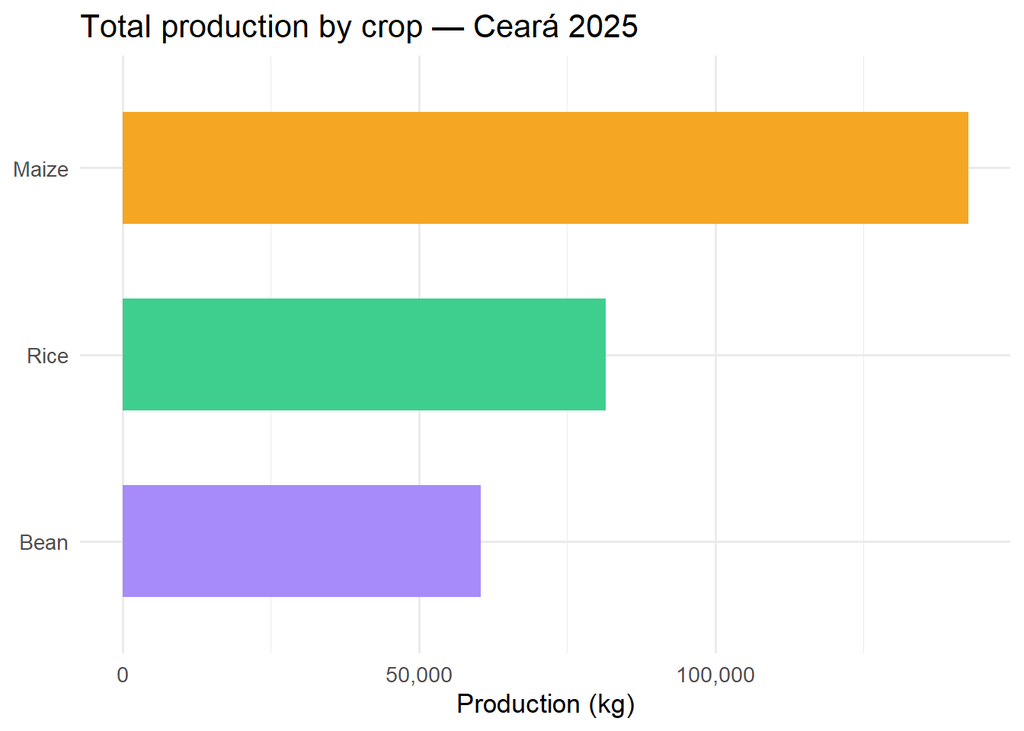

```r
# Simple bar chart — total production by crop
agriculture %>%
  group_by(crop) %>%
  summarise(total_prod_kg = sum(prod_kg, na.rm = TRUE)) %>%
  ggplot(aes(x = reorder(crop, total_prod_kg), y = total_prod_kg, fill = crop)) +
  geom_col(width = 0.6) +
  coord_flip() +
  scale_fill_manual(values = c(Bean = "#a78bfa", Maize = "#f5a623", Rice = "#3ecf8e")) +
  scale_y_continuous(labels = scales::comma) +
  labs(
    title    = "Total production by crop — Ceará 2025",
    x        = NULL,
    y        = "Production (kg)",
    fill     = NULL
  ) +
  theme_minimal(base_size = 13) +
  theme(legend.position = "none")
```

## Summary — SQL → tidyverse cheatsheet

| SQL | tidyverse | Notes |
| --- | --- | --- |
| SELECT col1, col2 | select(col1, col2) | Column names without quotes |
| SELECT * (all columns) | no verb needed / select(everything()) | Default is all columns |
| WHERE col = ‘x’ | filter(col == ‘x’) | Use == not = |
| WHERE col > 5 AND col2 = ‘y’ | filter(col > 5, col2 == ‘y’) | Comma = AND |
| WHERE col IN (‘a’,‘b’) | filter(col %in% c(‘a’,‘b’)) | Use %in% for lists |
| ORDER BY col DESC | arrange(desc(col)) | ASC is default |
| GROUP BY col | group_by(col) | Always pair with summarise() |
| SUM(col) AS total | summarise(total = sum(col, na.rm=TRUE)) | na.rm avoids NA results |
| COUNT(*) AS n | summarise(n = n()) | n() counts rows |
| JOIN t2 ON t1.key = t2.key | left_join(t2, by = ‘key’) | Keeps all rows from left table |
| SELECT DISTINCT col | distinct(col) | Remove duplicate values |

Dataset: Agricultural production, Ceará state, Brazil — 2025.  
Packages used: `tidyverse` (dplyr, ggplot2, readr).